# car_viz

Andrew Sisitzky

9/22/2021

The code begins by calling both the package 'tidyverse' and the built-in dataset 'mtcars'

```r
library(tidyverse)
# call built-in data mtcars.
data(mtcars)
```

```r
# Select only car models where mpg<20
mtcars_mpg2 <- mtcars[mtcars$mpg < 20,]

# Reduce the variables to mpg, cyl, disp, hp, gears
mtcars_mpg2 <- mtcars_mpg2[, c(1,2,3,4,10)]
```

We then use the R function 'source()' to link this file with the 'hand_functions.R' file in order to utilize a function within that file.

The following chunk calls the function 'sum_special' and uses it to calculate the data summary statistics of the 'mtcars_mpg2' dataset. This function calculates the mean, var, cov, and cor of 'mtcars_mpg2'

```r
# read the R file hand_functions.R so that it can be used
# notice that with echo = TRUE
source(file = "hand_functions.R", echo = TRUE)
```

```
##
## > sum_special <- function(df_x) {
## +     try(if (!is.data.frame(df_x))
## +         stop("Input data must be a data frame."))
## +     sp_means <- apply(df_ .... [TRUNCATED]
```

```r
# Now use the function from hand_functions.R
sp_out <- sum_special(mtcars_mpg2)
```

The next chunk of code shows the use of the equisser function in the esquisse package, however this code was kept as a comment as to not allow the chunk to compile. If it were to run, its purpose would be to create a plot with ggplot2, as we will do in the next section of code.

```r
# library(esquisse)
# esquisser(data = mtcars_mpg2, viewer = "browser")
```

In the next section, we create a plot of the mtcars_mpg2 dataset, where the variable disp is plotted on the x axis and mpg is plotted on the y axis. After the plot is created, this section of code uses geom_point to create a scatterplot of the data (where the points are bullet shaped, of size 4L, and of the color B22222) and geom_smooth is used to overlay the smoothed conditional means of the data. Finally, theme_minimal() sets the theme of the plot.

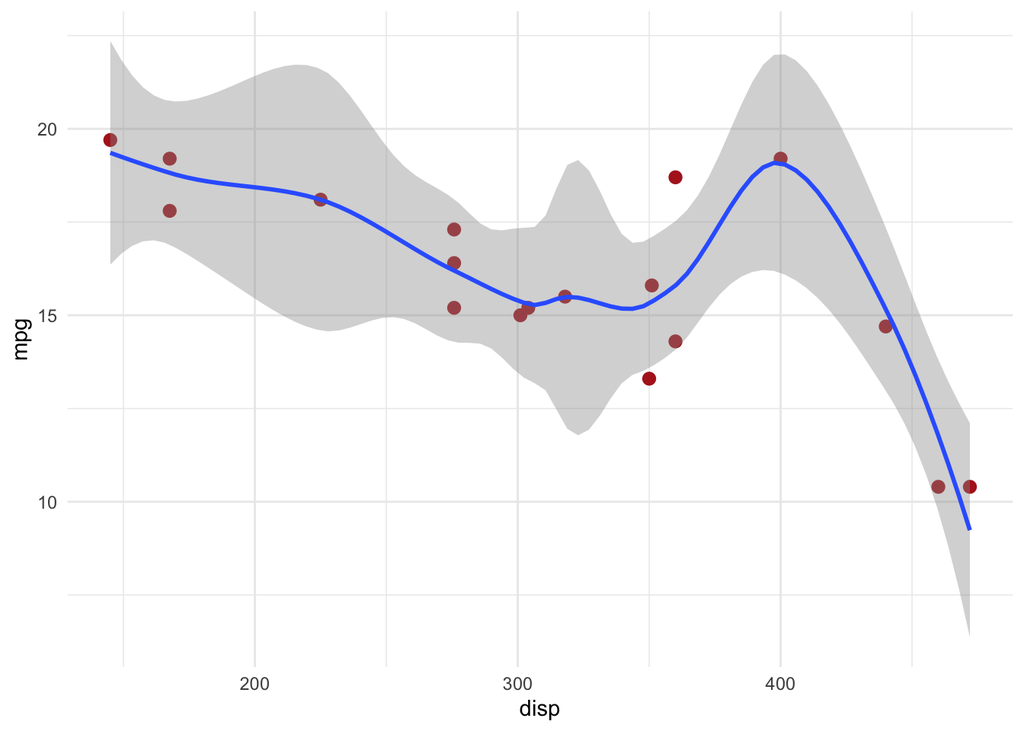

```r
ggplot(mtcars_mpg2) +
  aes(x = disp, y = mpg) +
  geom_point(shape = "bullet", size = 4L, colour = "#B22222") +
  geom_smooth(span = 0.5) +
  theme_minimal()
```

```r
# note that this boxplot cannot be made with esquisse() unless
# the data is adjusted.  What adjustment is needed?
```

In this final section of code, we use ggplot to once again plot data from the mtcars_mpg2 dataset. This time, the data on the x axis is the cyl variable converted to a factor and the mpg varaible on the y axis. This time, geom_boxplot is used to generate boxplots, as opposed to the scatterplot we saw in the previous plot.

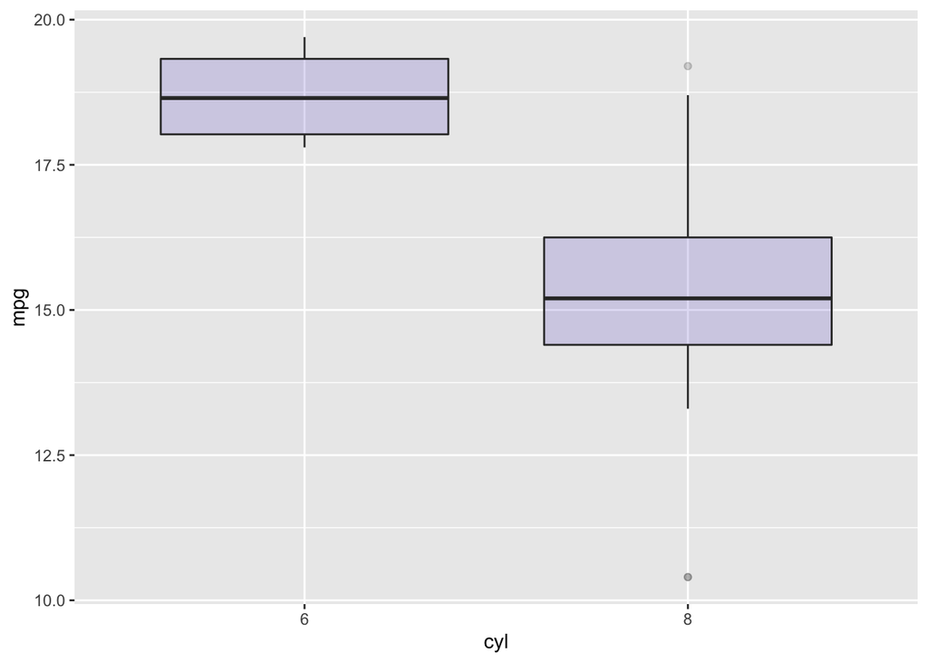

```r
ggplot(mtcars_mpg2, aes(x=as.factor(cyl), y=mpg)) +
  geom_boxplot(fill="slateblue", alpha=0.2) +
  xlab("cyl")
```